# 0080-Advanced R graphics with ggplot2

by Craig W. Slinkman

September 7, 2015

This document describes how to use the ggplot2 graphics to crerate professional looking graphics. We will only concentrate of graphics used in this course. We will not draw bar and pie charts in this course. We will concentrate on histograms, boxplots, and an brief introduction to scatterplots.

## Installing the ggplot2 package

Before we can draw any of the advanced graphics we will use in this course we must install and load the ggplot2 R-package. ON my computer the package has been installed so all I need to do is load with either the library command or the require command.

```r
require( ggplot2 )                     # Needed for professional quality
```

## Getting the data

We will start with the simplest histogram and then make it look more professional and useful in the steps. The data that we will use for our histograms is the daily return on Berkshire Hathaway Series A stock for the past business year. The data contains 261 days. We load the data below.

```r
fileName <-                    # Specify the file name.
    "BerkshireHathawayA.csv"
wd <- getwd()                  # Get working durectory.
path <-
    file.path( wd,             # Make path to the file.
               "data",
               fileName )

require( data.table )           # We will use data.tables.
BRK.A <- fread( path )          # Get data.

n <- dim( BRK.A )[1]

for( i in 2:n )BRK.A$Return[i] <- log(  BRK.A$BRK.A.Close[i]) -
                                  log(  BRK.A$BRK.A.Close[i-1])

BRK.A <- BRK.A[-1,]

write.csv( BRK.A, file=path )
```

## Histograms

Now that we have the data we will start drawing histograms starting with the most basic and ugliest histogram. We draw this histogram below.

### Basic histogram

The R-code needed to draw the histogram is shown below.

```
## stat_bin: binwidth defaulted to range/30. Use 'binwidth = x' to adjust this.
```

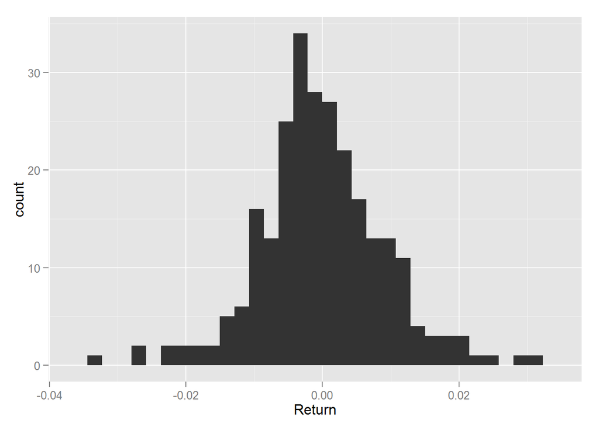

```r
ggplot( BRK.A,               # Specify data.frame or table.
        aes( x=Return )) +   # Specify variable to plot.
    geom_histogram()         # Specify geometric onject to plot.
```

### Adding lines ands colors

The above plot seems to lack detail because the lines and the fill colors are both black. We can change this be adding the a $color$ and $fill$ parameter to the $geom_histogram()$.

```
## stat_bin: binwidth defaulted to range/30. Use 'binwidth = x' to adjust this.
```

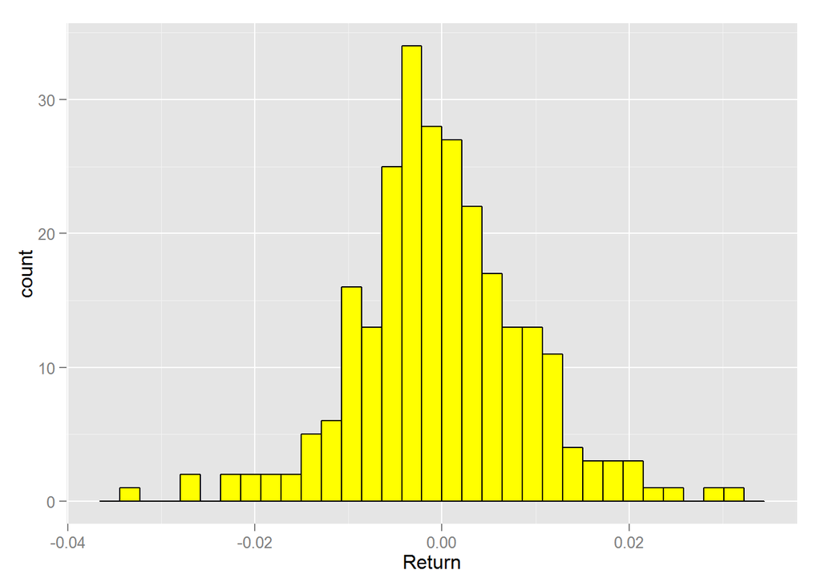

```r
ggplot( BRK.A,                       # Specify data.frame ortable.
        aes( x=Return )) +           # Specify variable to plot.
    geom_histogram( color="black",   # Draw histogram with black lines and yellow
                    fill="yellow" )  # fill.
```

### Changing the binwidth

Sometimes the default value of binwidth does not produce a histogram that communicates to the viewer adequately. We use the $binwidth$ parameter to change the binwidth. This parameter also is used in the $geom_histogram()$ function.

Binwidth should be some multiple of 10, 5, 2.5, or 2 to make it easier for persons to understand the plot.

#### A binwidth of 0.005

We first try a histogram with a $binwidth=0.005$.

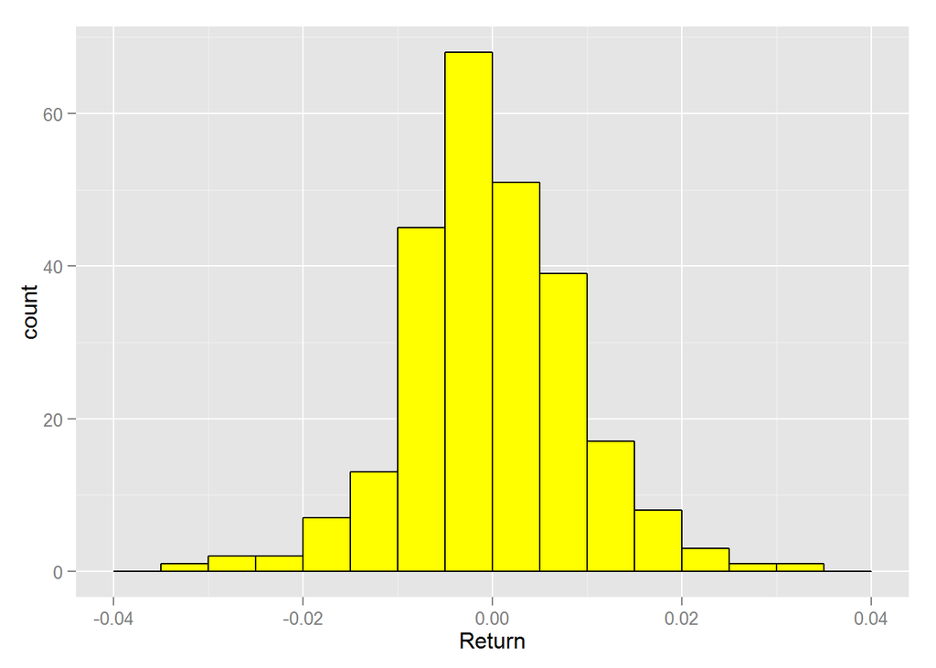

```r
ggplot( BRK.A,                       # Specify data.frame ortable.
        aes( x=Return )) +           # Specify variable to plot.
    geom_histogram( binwidth=0.005,  # Specify binwidth.
                    color="black",   # Draw histogram with black lines and yellow
                    fill="yellow" )  # fill.
```

Note how the histogram with binwidth of 0.005 produces a histogram that looks smoother and does not show the saw-tooth random effects that the default histogram showed.

We now try a binwidth of 0.0025

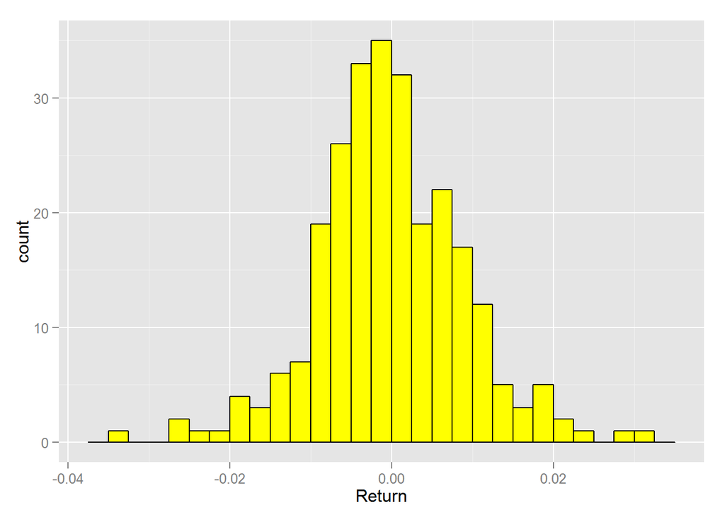

```r
ggplot( BRK.A,                        # Specify data.frame ortable.
        aes( x=Return )) +            # Specify variable to plot.
    geom_histogram( binwidth=0.0025,  # Specify binwidth.
                    color="black",    # Specify colors.
                    fill="yellow" )   # fill.
```

This histogram with a $binwidth=0.0025$ shows random saw-tooth effects. This indicative of a binwidth that is too small.

### Add a kernal smoother

A kernel smoother ( https://en.wikipedia.org/wiki/Kernel_smoother ) is a statistical technique for estimating a real valued function f(X),,( X^{p} ) by using its noisy observations, when no parametric model for this function is known. The estimated function is smooth, and the level of smoothness is set by a single parameter.

This technique is most appropriate for low-dimensional (p < 3) data visualization purposes. Actually, the kernel smoother represents the set of irregular data points as a smooth line or surface.

Below we use a $binwidth=0.005$ and add the geometric object $geom_density$ to our plot to add the smooth.

WE we use density smoother we must change the y-axis to a density. To do this we must use the aesthetics function $aes$ in the geom_histogram function

The density is computed so that the total area in the histogram is equal to one.

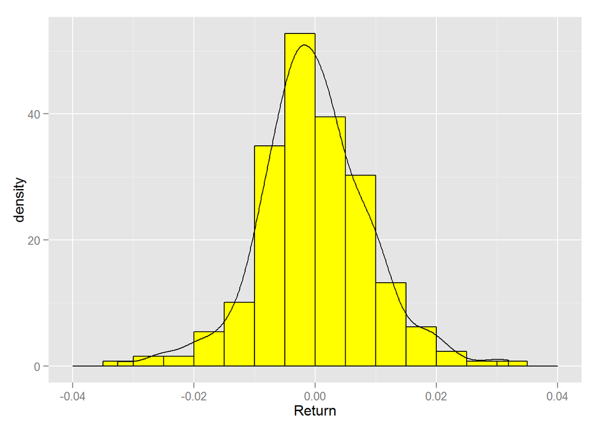

```r
ggplot( BRK.A,                            # Specify data.frame ortable.
        aes( x=Return )) +                # Specify variable to plot.
    geom_histogram( aes( y=..density..),  # Specify a density plot.
                    binwidth=0.0050,      # Specify binwidth.
                    color="black",        # Specify colors.
                    fill="yellow" ) +     # fill.
    geom_density( )                       # Add density plot.
```

### Adding a rug plot to the histogram

A rug plot gives us an intuitive understanding of the density of data points along the x-axis of the histogram.

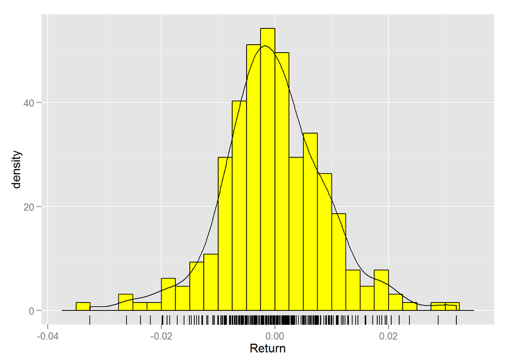

```r
ggplot( BRK.A,                            # Specify data.frame ortable.
        aes( x=Return )) +                # Specify variable to plot.
    geom_histogram( aes( y=..density..),  # Specify a density plot.
                    binwidth=0.0025,      # Specify binwidth.
                    color="black",        # Specify colors.
                    fill="yellow" ) +     # fill.
    geom_density( ) +                     # Add snothed density plot
    geom_rug()                            # Add rug plot.
```

### Modify x and y axis labels

We modify the x and y axis labels using the $xlab()$ and $ylab$ functions.

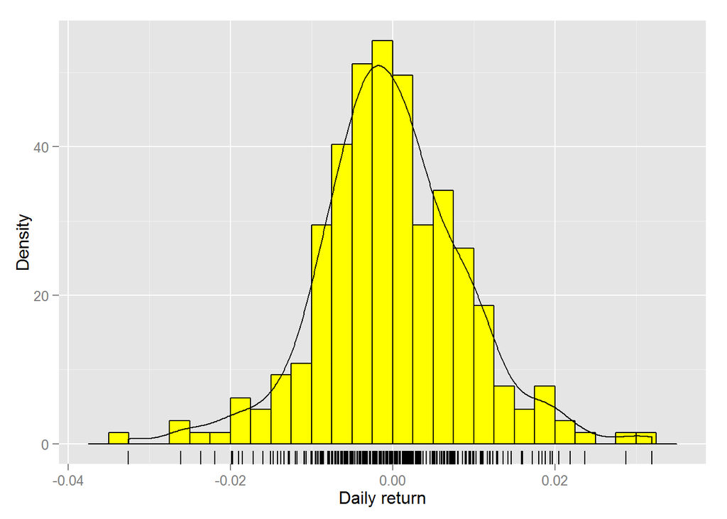

```r
ggplot( BRK.A,                            # Specify data.frame ortable.
        aes( x=Return )) +                # Specify variable to plot.
    geom_histogram( aes( y=..density..),  # Specify a density plot.
                    binwidth=0.0025,      # Specify binwidth.
                    color="black",        # Specify colors.
                    fill="yellow" ) +     # fill.
    geom_density( ) +                     # Add snothed density plot
    geom_rug() +                          # Add rug plot.
    xlab( "Daily return") +               # Modify x-axis label.
    ylab( "Density" )                     # Modify y-axis label.
```

### Adding a title

We add a title with the $ggtitle()$ function.

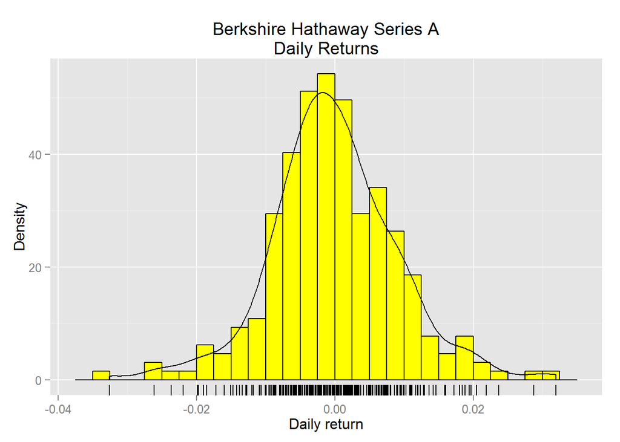

```r
ggplot( BRK.A,                            # Specify data.frame ortable.
        aes( x=Return )) +                # Specify variable to plot.
    geom_histogram( aes( y=..density..),  # Specify a density plot.
                    binwidth=0.0025,      # Specify binwidth.
                    color="black",        # Specify colors.
                    fill="yellow" ) +     # fill.
    geom_density( ) +                     # Add snothed density plot
    geom_rug() +                          # Add rug plot.
    xlab( "Daily return") +               # Modify x-axis label.
    ylab( "Density" )  +                  # Modify y-axis label.
    ggtitle( "Berkshire Hathaway Series A\nDaily Returns" )
```

## Boxplots ( https://en.wikipedia.org/wiki/Box_plot )

In descriptive statistics, a box plot or boxplot is a convenient way of graphically depicting groups of numerical data through their quartiles. Box plots may also have lines extending vertically from the boxes (whiskers) indicating variability outside the upper and lower quartiles, hence the terms box-and-whisker plot and box-and-whisker diagram. Outliers may be plotted as individual points. Box plots are non-parametric: they display variation in samples of a statistical population without making any assumptions of the underlying statistical distribution. The spacings between the different parts of the box indicate the degree of dispersion (spread) and skewness in the data, and show outliers. In addition to the points themselves, they allow one to visually estimate various L-estimators, notably the interquartile range, midhinge, range, mid-range, and trimean. Boxplots can be drawn either horizontally or vertically.

### Univariate boxplot

Suppose we wish to draw a boxplot of the distribution Berkshire Hathaway daily returns. The R-code for this is given below

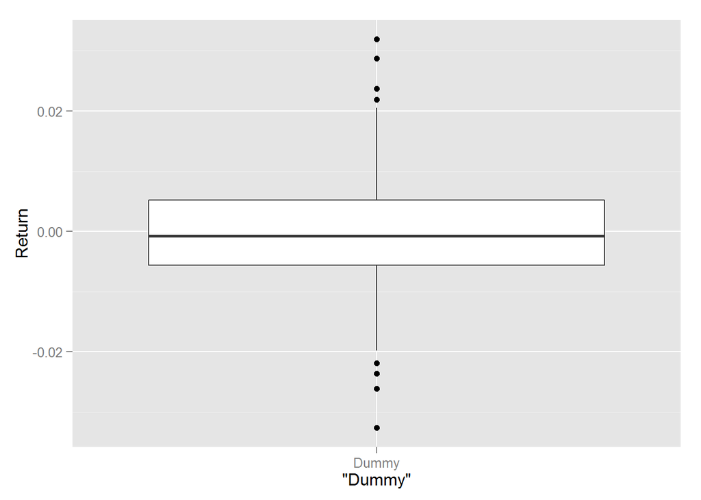

```r
ggplot( BRK.A,                      # Specify dara
        aes( x="Dummy",             # boxplot requires an x variable
             y=Return )) +          # and a y variable.
    geom_boxplot( )                 # Obkect is a boxplot
```

### Supressing the “Dummy variable”

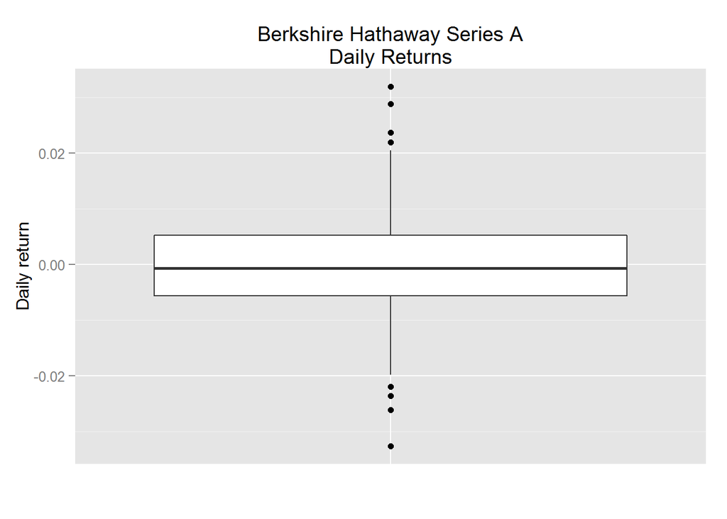

```r
ggplot( BRK.A,                             # Specify dara
        aes( x="",                         # boxplot requires an x variable
             y=Return )) +                 # and a y variable.
    geom_boxplot( ) +                      # Object is a boxplot.
    theme(axis.ticks.x=element_blank()) +  # Supress axis ticks
    xlab( "" ) +                           # Suppress label on x-axis.
    ylab( "Daily return") +                # Modify ylabel
     ggtitle( "Berkshire Hathaway Series A\nDaily Returns" )
```

Note that if the returns are normally distributed then the probability that a single return will be declared an outlier is 0.007%. Hence, the probability of 8 outliers if the distribution is normal is $0.007^8=5.764801\times 10^{-18}$. The observed sample results are very unlikely if the data is a normal distribution. Therefore, we conclude that the data does not appear to be a normal distribution.

### Rotating the boxplot axis

Some people would prefer to get the “Daily return scale” on the x-axis. We can do this by using the $ggplot2$ function $coord_flip$. We simply add to our prior boxplot specification.

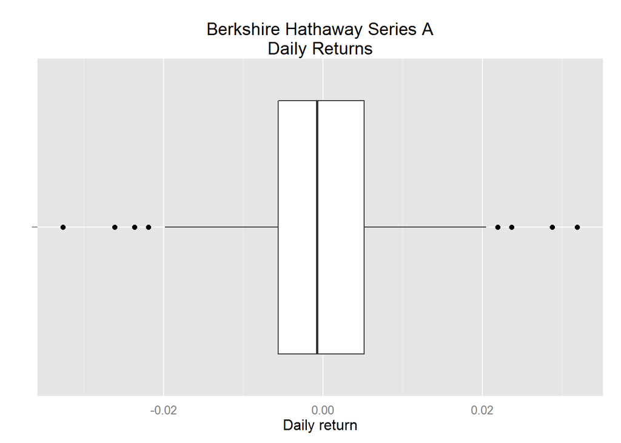

```r
ggplot( BRK.A,                             # Specify data.
        aes( x="",                         # boxplot requires an x variable
             y=Return )) +                 # and a y variable.
    geom_boxplot( ) +                      # Object is a boxplot.
    theme(axis.ticks.x=element_blank()) +  # Supress axis ticks
    xlab( "" ) +                           # Suppress label on x-axis.
    ylab( "Daily return") +                # Modify y-label.
    coord_flip() +                          # Swap x and y ax
    ggtitle( "Berkshire Hathaway Series A\nDaily Returns" )
```

### Using boxplots with one qualatative variable and one quantitative variable

Some times the value of a qualtative variablle will will be associated with the value a quantitative variables. Comparitive boxplots are uswful fir showing the behavior.

#### Reading the KBSRevenue.cvs file

```r
fileName <- "KBSRevenue.csv"         # Specifdy file name.
wd <- getwd()                        # Get working directory.
filePath <-                          # Build file path.
    file.path(wd,
              "data",
              fileName )

require( data.table )                # For fread functionality.

KBS <- fread( filePath )             # Read file into data.table.

KBS$Revenue <- as.numeric(  KBS$Revenue  )
KBS <-                               #Wliminate missing values.
    KBS[ complete.cases( KBS)]
```

We must chnage the Mnnth variable form a charcter to an ordered factor. If we do not do this the output will be in alpahbetical order

```r
KBS$Month <-
    factor( KBS$Month,
            levels = c( "Jan", "Feb", "Mar",
                        "Apr", "May", "Jun",
                        "Jul,","Aug", "Sep",
                        "Oct", "Nov", "Dec" ))
```

Now we plot comaprivie boxplots where the x-variable is month and the y-variablew is revenue.

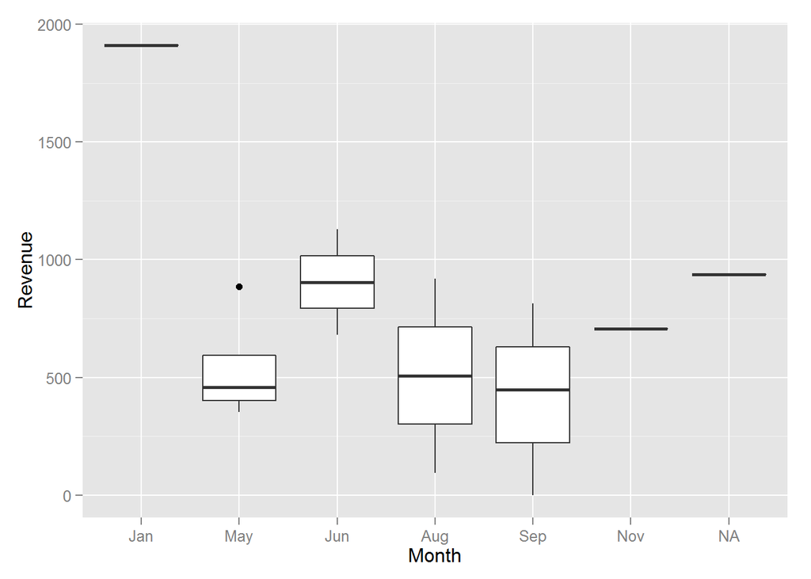

```r
ggplot( KBS,
        aes( x=Month,
             y=Revenue )) +
    geom_boxplot()
```

## Simple scatterplots

We often investigate the linear statistical relationship between two quantative random variables with a scatter plot.

- We plot the predictor (sometimes incoreectly called the independent variable) on the X-axis.
- We plot the response variable (somtimes incorrectly called the depencent varaible ) on the Y-axis.

### Example: Fire department response

```
head( ResponseTime, n=5 )
tail( ResponseTime, n=5 )
```

The basic command to plot the scatterplot is shown below:

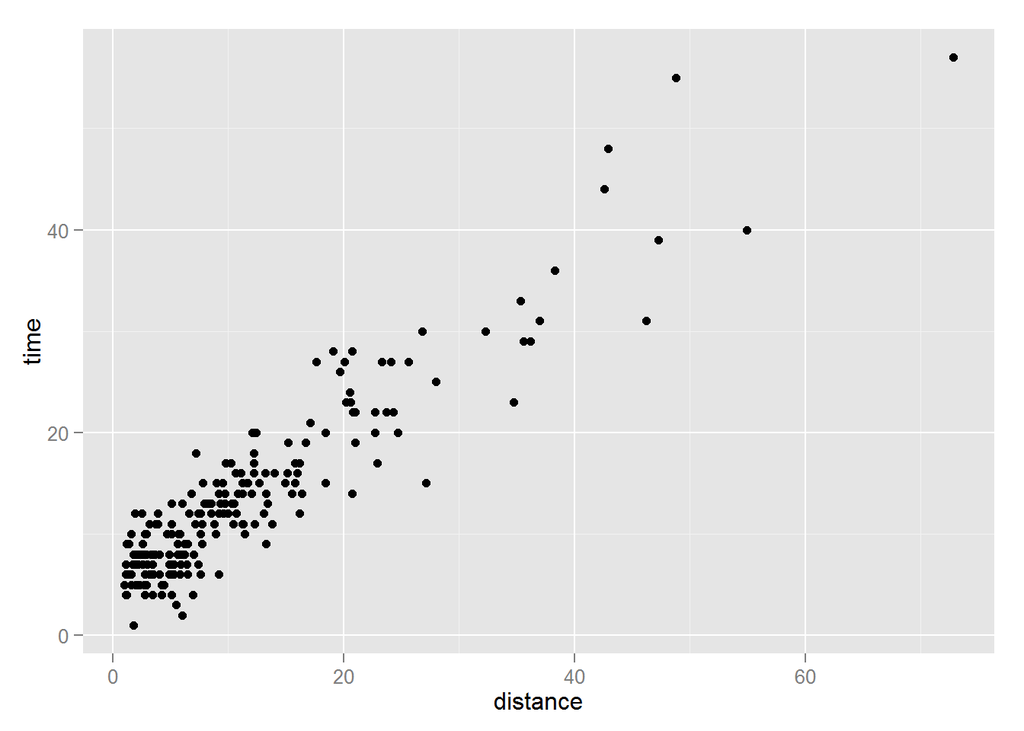

```r
library( ggplot2 )
ggplot( ResponseTime,                  # Specify data source.
        aes( x=distance,               # Specify predictor variable.
             y=time)) +                # Specify response variable.
    geom_point()                       # Plot points
```

### Adding the labels and the title We now add the labels and the plot title.

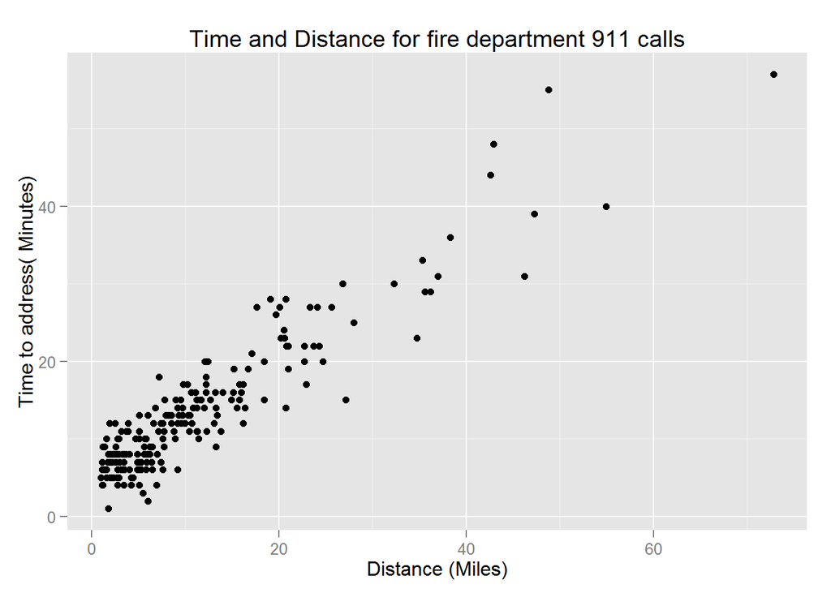

```r
library( ggplot2 )
ggplot( ResponseTime,                      # Specify data source.
        aes( x=distance,                   # Specify predictor variable.
             y=time)) +                    # Specify response variable.
    geom_point() +                         # Plot points
    xlab( "Distance (Miles)" )  +          # Modify X-axis label.
    ylab( "Time to address( Minutes)" ) +  # Modify Y-axis label
    ggtitle( "Time and Distance for fire department 911 calls")
```

## Berhshire Hathaway capital Asset pricing model

One of the most important concepts in Finanace is the Capital Asset Pricing model (CAPM ). This model measures how the return on a security chnages as the return on a market index changes.

We plot this data for the last business year.

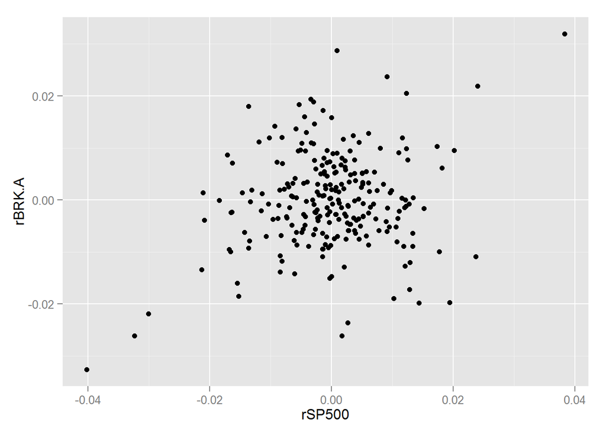

```r
inFile <- file.path( getwd(),                    # Get path to data.
                     "data",
                     "capmBRKa.csv" )
library( data.table )                            # Needed for fread
BRK.A <- fread( inFile, header=TRUE )            # Read data file

ggplot( BRK.A,                                   # Data source.
        aes( x = rSP500,                         # Return on SP500 on X-axis.
             y= rBRK.A )) +                      # Return of BRK.A on Y-axiis,
    geom_point()                                 # Add points.
```

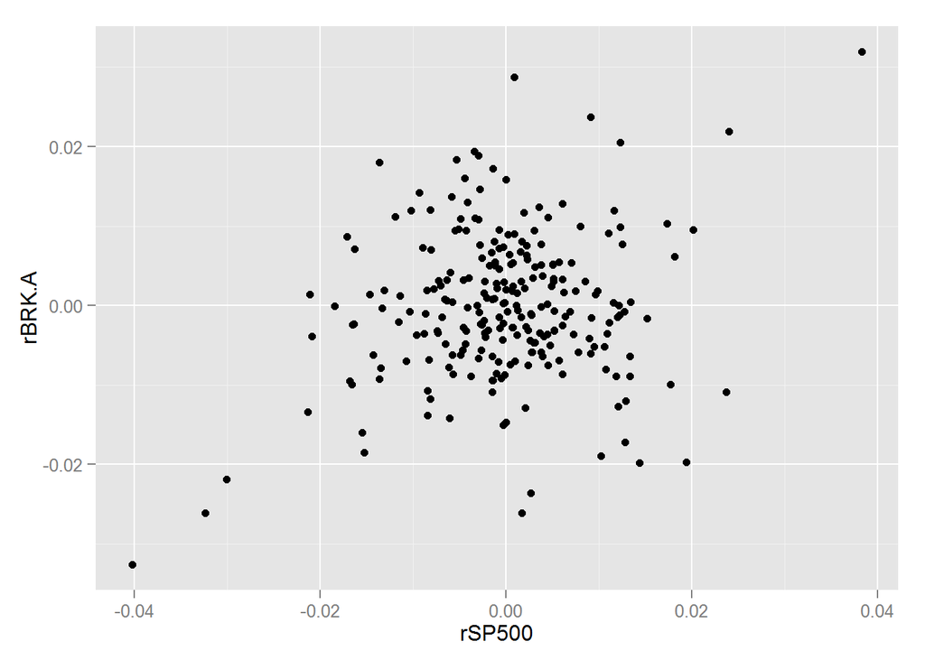

```r
ggplot( BRK.A,                                   # Data source.
        aes( x = rSP500,                         # Return on SP500 on X-axis.
             y= rBRK.A )) +                      # Return of BRK.A on Y-axiis,
    geom_point()                                 # Add points.
```

```r
    geom_smooth( method=lm )                     # Add slr line.
```

[output not shown]

```r
BRK.A <- BRK.A[ complete.cases(BRK.A),]
XY <- cbind( BRK.A$rSP500, BRK.A$rBRK.A )
XY <- as.matrix( XY )
cor( XY )
```

```
##           [,1]      [,2]
## [1,] 1.0000000 0.1948855
## [2,] 0.1948855 1.0000000
```

```r
model <- lm( rBRK.A ~ rSP500, data=BRK.A )
round( coef( model ),5 )
```

```
## (Intercept)      rSP500
##    -0.00003     0.19174
```